# Exploratory Data Analysis: Hands-on

Uijeong “UJ” Hwang

2026-09-28

# Yoga Studios and Gentrification

Gentrification is the process of urban transformation in which neighborhoods undergo socioeconomic changes, typically characterized by an influx of higher-income residents and investment. This often leads to increased property values and rents, which can displace lower-income residents and alter the cultural landscape of the area. While gentrification can improve infrastructure and amenities, it raises concerns about social equity, displacement, and the loss of community identity.

> “Seemingly overnight, a yoga studio replaces a barbershop, a coffee café takes over a small grocery, and a multi-story apartment building looms where older single-family homes once stood.” ([Katharine Miller, 2024](https://hai.stanford.edu/news/spotting-visual-signs-gentrification-scale))

In today’s lab session, you will be answering this question: *Are yoga studios associated with gentrification?*

## Operational Definition of Gentrification

Gentrification is about change; the transformation of a neighborhood once affordable becoming unaffordable, so we have two conditions: “*once affordable*” and “*becoming unaffordable*”.

To create a simple operational definition, let’s say:

- Measure of affordability: Median gross rent for 2-bedroom
- Time period: 2015 - 2024
- “Once affordable”: **2-bedroom rent in 2015 was below median value**
- “Becoming unaffordable”: **2-bedroom rent in 2024 is above median value** or **the change in rent between 2015 and 2024 is very high**

Then we use the data to define neighborhood type by gentrification status: *Affordable*, *Unaffordable*, and *Gentrifying*

|  | **Becoming unaffordable** | **Not becoming unaffordable** |
| --- | --- | --- |
| **Affordable in 2015** | **Gentrifying** | Affordable |
| **Not affordable in 2015** | Unaffordable | Unaffordable |

# Data Collection and Manipulation

We need:

- Census ACS “Median gross rent for 2-bedroom” data for 2015 and 2024 in Fulton and DeKalb Counties
- Yoga studios within the two counties (will be provided)

## Census ACS

### Get ACS data

Let’s first download the ACS 5-year estimate data for 2015 and 2024 for the two counties at the Tract level.

```r
census_api_key(Sys.getenv(????))

tract_2015 <- suppressMessages(
  get_acs(geography = ????,
          state = "GA",
          county = c("Fulton", "Dekalb"),
          variables = c(median_rent_2br = "B25031_004E"),
          year = ????,
          survey = ????,
          geometry = ????,
          output = ????)) %>%
  select(GEOID, median_rent_2br_2015 = median_rent_2br)

tract_2024 <- suppressMessages(
  get_acs(geography = ????,
          state = "GA",
          county = c("Fulton", "Dekalb"),
          variables = c(median_rent_2br = "B25031_004E"),
           year = ????,
          survey = ????,
          geometry = ????,
          output = ????)) %>%
  select(GEOID, median_rent_2br_2024 = median_rent_2br)
```

```
## To install your API key for use in future sessions, run this function with `install = TRUE`.
```

### Visualize the data

Note that `tmap` functions in this document are based on `tmap` v4. If you are using `tmap` v3 (check with `packageVersion("tmap")`), consider upgrading to v4 using `update.packages` or `install.packages`.

```r
atlanta_decatur <- places("GA", progress_bar = F) %>%
  filter(NAME %in% c("Atlanta","Decatur"))

tm_shape(tract_2015) + tm_fill(fill = "median_rent_2br_2015") +
  tm_shape(atlanta_decatur) + tm_borders(col = "black", lwd = 2)
```

[interactive chart not shown]

```r
tm_shape(tract_2024) + tm_fill(fill = "median_rent_2br_2024") +
  tm_shape(atlanta_decatur) + tm_borders(col = "black", lwd = 2)
```

[interactive chart not shown]

> Why so many missing values?

### Wait, Boundaries don’t match!

Census boundary changes every 10 years, which means 2015 data and 2024 data use different geometries We first need to align these boundaries to enable a direct comparison of rent values over time.

```r
print(nrow(tract_2015))
```

```
## [1] 349
```

```r
print(nrow(tract_2024))
```

```
## [1] 530
```

```r
tm_shape(tract_2024) + tm_borders(col = "#ebe300", lwd = 5) +
  tm_shape(tract_2015) + tm_borders(col = "#ff5c5c", lwd = 2) +
  tm_view(set_view = c(-84.397671, 33.776624, 13))
```

[interactive chart not shown]

### Spatial join

To make 2015 ACS tract-level data comparable with 2024 tract boundaries, we will perform a spatial intersection between the two sets of geometries. For each overlap, we will calculate an area-weighted contribution of the 2015 median 2-bedroom rent, so that larger overlaps contribute proportionally more to the final value. After weighting, we will aggregate these contributions to the 2024 tract level, which will give us a dataset where rent values from 2015 and 2024 are directly comparable on the same set of boundaries.

Note: In the code chunk below, `tract_2015 %<>%` is shorthand for `tract_2015 <- tract_2015 %>%`. To use this special pipe, you need to load the `magrittr` package.

```r
# Convert CRS from GCS to PCS before spatial operation and fix invalid geometries
tract_2015 %<>% st_transform(32616) %>% st_make_valid()
tract_2024 %<>% st_transform(32616) %>% st_make_valid()

# Spatial intersection join. Which two layers are we overlaying?
tract_intersect <- st_intersection(???? %>% rename(GEOID_2015 = GEOID),
                                   ???? %>% rename(GEOID_2024 = GEOID))

# Compute area of each overlap and use it as a weight
tract_intersect %<>%
  mutate(area_overlap = as.numeric(st_area(.)),
         median_rent_2br_2015_weighted = median_rent_2br_2015 * area_overlap)

# Aggregate 2015 rent values to the 2024 tract level.
# We want one row per NEW tract, so which ID should the rows be grouped by?
tract_2015_aligned <- tract_intersect %>%
  group_by(????) %>%
  summarize(
    median_rent_2br_2015_aligned =
      (sum(median_rent_2br_2015_weighted, na.rm = TRUE) / sum(????, na.rm = TRUE)) %>% round(2)
  )

# Join the aligned 2015 rent values back to 2024 tracts
tract <- left_join(tract_2024,
                   tract_2015_aligned %>%
                     st_drop_geometry() %>%
                     select(GEOID = GEOID_2024, median_rent_2br_2015 = median_rent_2br_2015_aligned),
                   by = "GEOID")
```

The following figure illustrates what we just did.

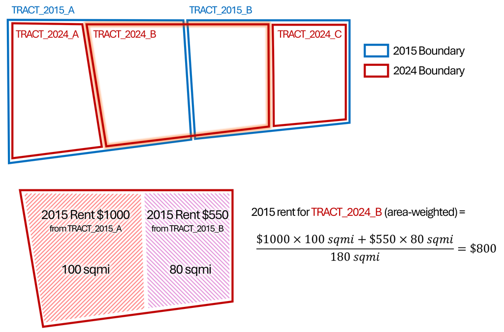

### Get changes in median gross rent for 2-bedroom

Calculate the change of median gross rent for 2-bedroom between 2015 and 2024. Then, remove Tracts with missing values or anomalies.

```r
tract %<>%
  mutate(
    # Proportional change = (new value - old value) / old value
    median_rent_2br_change = (???? - ????)/median_rent_2br_2015
    ) %>%
  drop_na(median_rent_2br_change) %>%
  filter(median_rent_2br_2015 > 300 & median_rent_2br_change < 3)
```

### Summarize and visualize the data

```r
print(paste0("Median value of median 2-bedroom rent in 2015: $",
             median(tract$median_rent_2br_2015) %>% round(2)))
```

```
## [1] "Median value of median 2-bedroom rent in 2015: $997.8"
```

```r
print(paste0("Median value of median 2-bedroom rent in 2024: $",
             median(tract$median_rent_2br_2024) %>% round(2)))
```

```
## [1] "Median value of median 2-bedroom rent in 2024: $1785"
```

```r
print(paste0("Median change of the median 2-bedroom rent between 2015 and 2024: ",
             median(tract$median_rent_2br_change*100) %>% round(1), "%"))
```

```
## [1] "Median change of the median 2-bedroom rent between 2015 and 2024: 68.6%"
```

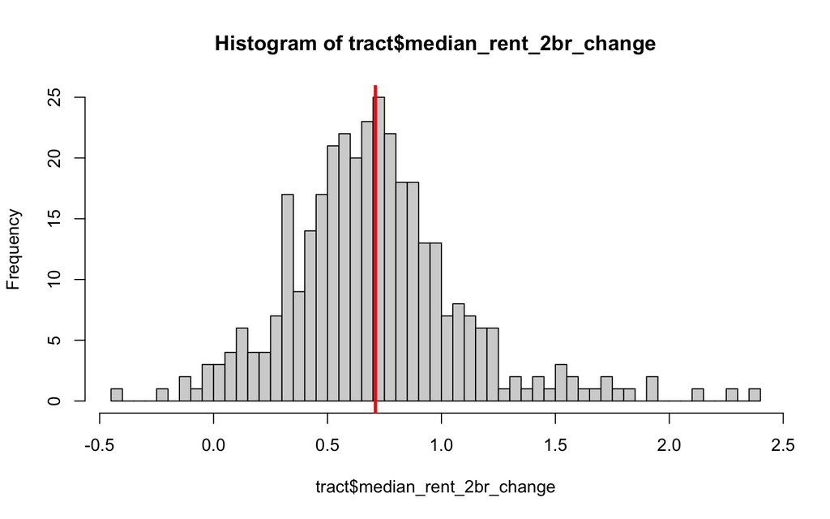

```r
hist(tract$median_rent_2br_change, breaks = 50)
abline(v = mean(tract$median_rent_2br_change), col = "red", lwd = 3)
```

```r
tm_shape(tract) + tm_fill(fill = "median_rent_2br_change",
                          fill.scale = tm_scale(values = "magma")) +
  tm_shape(atlanta_decatur) + tm_borders(col = "#00ace0", lwd = 2) +
  tm_view(set_view = c(-84.397671, 33.776624, 11))
```

[interactive chart not shown]

> Do these numbers, the plot, and the map make sense to you?

### Neighborhood type by gentrification status

Classify Census Tracts into the three categories we defined: “Gentrifying,” “Affordable,” and “Unaffordable”. Review the `case_when()` documentation to understand how the function evaluates conditions and returns the corresponding values sequentially.

```r
# `case_when()` stops at the FIRST condition that is TRUE, so the order of these
# three lines is part of the definition -- not a style choice.
tract %<>%
  mutate(gentri_category = case_when(
    median_rent_2br_2015 >= median(median_rent_2br_2015) ~ "????",
    median_rent_2br_2024 >= median(median_rent_2br_2024) | median_rent_2br_change >= 1 ~ "????",
    ???? ~ "Affordable"))  # what catches every row that matched neither condition?
```

How many Tracts are gentrifying between 2015 and 2024?

```r
table(tract$gentri_category)
```

```
##
##   Affordable  Gentrifying Unaffordable
##          132           40          173
```

### Let’s see which neighborhoods are gentrifying.

```r
tm_shape(tract) + tm_fill(col = "gentri_category", palette = c("lightblue", "red", "pink")) +
  tm_shape(atlanta_decatur) + tm_borders(col = "black", lwd = 2) +
  tm_view(set.view = c(-84.397671, 33.776624, 11))
```

[interactive chart not shown]

```r
tm_basemap("OpenStreetMap") +
  tm_shape(tract %>% filter(gentri_category == "Gentrifying")) + tm_borders(col = "red", lwd = 4) +
  tm_shape(atlanta_decatur) + tm_borders(col = "black", lwd = 2) +
  tm_view(set.view = c(-84.397671, 33.776624, 11))
```

[interactive chart not shown]

## Yoga Studio POIs

### Load the POI data

**We will use the Google Places POI data that has already been downloaded for today’s class.**

This data covers Fulton and DeKalb Counties, GA, and includes all Google Places entries with the place type `"yoga_studio"`.

```r
yoga <- st_read("https://raw.githubusercontent.com/ujhwang/urban-analytics-2026/main/Lab/module_2/week1/yoga_studios_fulton_dekalb.geojson")
```

Remove POIs without any review rating (i.e., missing values in `rating_count`).

```r
# `yoga %<>%` is a shorter version of `yoga <- yoga %>%`
yoga %<>% ????
```

### Let’s see if the results look fine

Get a summary using `skimr::skim()` and display the locations of yoga studios on the Census Tract map.

```r
skim(yoga)
```

Data summary

| Name | yoga |
| --- | --- |
| Number of rows | 153 |
| Number of columns | 8 |
| _______________________ |  |
| Column type frequency: |  |
| character | 6 |
| numeric | 2 |
| ________________________ |  |
| Group variables | None |

**Variable type: character**

| skim_variable | n_missing | complete_rate | min | max | empty | n_unique | whitespace |
| --- | --- | --- | --- | --- | --- | --- | --- |
| id | 0 | 1.00 | 27 | 27 | 0 | 153 | 0 |
| name | 0 | 1.00 | 7 | 67 | 0 | 147 | 0 |
| primary_type | 3 | 0.98 | 3 | 24 | 0 | 16 | 0 |
| types | 0 | 1.00 | 109 | 253 | 0 | 52 | 0 |
| review_summary | 101 | 0.34 | 91 | 395 | 0 | 52 | 0 |
| geometry | 0 | 1.00 | 23 | 26 | 0 | 152 | 0 |

**Variable type: numeric**

| skim_variable | n_missing | complete_rate | mean | sd | p0 | p25 | p50 | p75 | p100 | hist |
| --- | --- | --- | --- | --- | --- | --- | --- | --- | --- | --- |
| rating | 0 | 1 | 4.73 | 0.51 | 1 | 4.7 | 4.9 | 5 | 5 | ▁▁▁▁▇ |
| rating_count | 0 | 1 | 141.48 | 378.38 | 1 | 16.0 | 41.0 | 114 | 2692 | ▇▁▁▁▁ |

```r
tm_shape(yoga) + tm_dots(fill="red") +
  tm_shape(tract) + tm_borders() +
  tm_shape(atlanta_decatur) + tm_borders(col = "black", lwd = 2)
```

[interactive chart not shown]

### Join the yoga studio data to Census Tract data

We aim to determine the presence of yoga studios at the Census Tract level. To achieve this, we will:

1. Spatial join the two datasets.
2. Get a vector of GEOIDs for all Census Tracts that have at least one yoga studio (many tracts will have none).
3. Use these GEOIDs to create a boolean column indicating whether a yoga studio is present in each Tract.

```r
## Make sure the CRS of the two sf objects are in the same PCS
tract %<>% st_transform(????)
yoga %<>% st_transform(????)

# Join yoga studios with tracts
tract_yoga <- st_join(????, ????)

# Get the presence of yoga studios at the tract level
geoid_tracts_with_yoga <- tract_yoga %>%
  filter(!is.na(name)) %>%
  pull(GEOID) %>%
  unique()

# Join the presence of yoga studios to `tract`
tract %<>% mutate(yoga = GEOID %in% ????)
```

### Confirm the spatial join was done correctly

Visually check that the spatial join worked as intended by plotting the presence of yoga studios and overlaying the original yoga studio locations.

```r
tm_shape(????) + tm_fill(fill=????) +
  tm_shape(????) + tm_dots()
```

[interactive chart not shown]

# Exploring the Association

## Now we are ready to ask some probing questions about the data

Are yoga studios in **gentrifying neighborhoods**?

```r
tm_shape(tract) + tm_fill(fill=????) +
  tm_shape(yoga) +tm_dots()
```

[interactive chart not shown]

> It appears that most yoga studios are located in “unaffordable” neighborhoods.

Let’s see the proportion of Census Tracts with at least yoga studio by neighborhood type.

[output not shown]

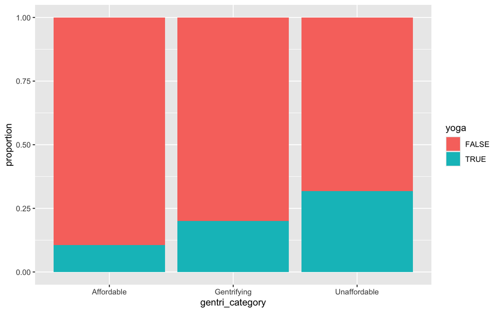

```r
yoga_summary <- tract %>%
  st_drop_geometry() %>%
  # One row for every combination of "has a yoga studio?" and neighborhood type
  group_by(????, ????) %>%
  summarize(n = n()) %>%
  ungroup() %>%
  mutate(proportion = n / sum(n))

yoga_summary %>%
  ggplot(aes(x = gentri_category, y = proportion, fill = yoga)) +
  geom_bar(stat = 'identity', position = 'fill')
```

> Gentrifying neighborhoods have more yoga studios than affordable neighborhoods, but less than already unaffordable neighborhoods.

## Regression model

### Model specification

- Model type: Binomial logistic regression
- Dependent variable: **Presence of yoga studios**
- Independent variable: **Neighborhood type by gentrification status**
- Control variables:
  - **Educational attainment** (Rationale: higher education levels may correlate with interest in wellness activities such as yoga.)
  - **Median household income** (Rationale: income levels can influence the affordability and demand for amenities like yoga studios.)
  - **Median age** (Rationale: Age demographics may affect lifestyle preferences and demand for fitness-related amenities.)
  - **Non-family household** (Rationale: neighborhoods with higher shares of single or non-family households may have greater demand for lifestyle-oriented amenities, including yoga studios.)
  - **Racial/ethnic composition** (Rationale: the demographic makeup of a community might correlate with cultural or lifestyle preferences that influence yoga studio presence.)
  - **Population who commute by walking/biking** (Rationale: pedestrian/cyclist-friendly areas may be more likely to have yoga studios)
  - **Population density** (Rationale: denser areas provide a larger customer base and foot traffic, increasing the likelihood of yoga studios opening and sustaining operations.)

### Collect data for the control variables

```r
tract_control_vars <- suppressMessages(
  get_acs(geography = ????,
          state = ????,
          county = ????,
          variables = c(pop = "B01003_001E",
                        edu_associate = "B06009_004E",
                        edu_bachelor = "B06009_005E",
                        edu_graduate = "B06009_006E",
                        edu_total = "B06009_001E",
                        hhincome = "B19013_001E",
                        median_age = "B01002_001E",
                        nonfamily_hh = "B11001_007E",
                        hh = "B11001_001E",
                        non_hispanic_white = "B03002_003E",
                        race_ethnic_total = "B03002_001E",
                        commute_walk = "B08006_015E",
                        commute_bike = "B08006_014E",
                        commute_total = "B08006_001E"),
          year = 2024,
          survey = ????,
          geometry = TRUE,
          output = ????)) %>%
  mutate(high_edu_pct = (edu_associate + edu_bachelor + edu_graduate)/edu_total,
         minority_pct = (race_ethnic_total - non_hispanic_white)/race_ethnic_total,
         commute_walk_pct = commute_walk/commute_total,
         commute_bike_pct = commute_bike/commute_total,
         nonfamily_hh_pct = nonfamily_hh/hh)

# Calculate land area of Census Tract and get population density using the area
tract_control_vars %<>%
  mutate(area = st_area(.) %>% set_units(mi^2)) %>%
  mutate(pop_density = pop/area)

# Remove unnecessary columns including geometry
tract_control_vars %<>%
  select(GEOID, high_edu_pct, hhincome, median_age, minority_pct,
         commute_walk_pct, commute_bike_pct, pop_density, nonfamily_hh_pct) %>%
  st_drop_geometry()

# Join the control variables to the original Tract data
model_data <- tract %>% left_join(tract_control_vars, by = ????)
```

### Run the model

Since our dependent variable is the presence of yoga studio (TRUE/FALSE), Let’s run a binomial logistic regression model using `glm()`.

```r
# Which column is the outcome we are trying to explain?
# And which `family` does a TRUE/FALSE outcome call for?
m1 <- glm(???? ~ gentri_category + high_edu_pct + hhincome + median_age + nonfamily_hh_pct +
            minority_pct + commute_walk_pct + commute_bike_pct + pop_density,
          data=model_data, family = "????")

????(m1)
```

```
##
## Call:
## glm(formula = yoga ~ gentri_category + high_edu_pct + hhincome +
##     median_age + nonfamily_hh_pct + minority_pct + commute_walk_pct +
##     commute_bike_pct + pop_density, family = "binomial", data = model_data)
##
## Coefficients:
##                               Estimate Std. Error z value Pr(>|z|)
## (Intercept)                 -9.952e-01  2.222e+00  -0.448   0.6542
## gentri_categoryGentrifying  -4.690e-02  5.929e-01  -0.079   0.9369
## gentri_categoryUnaffordable  3.457e-01  5.093e-01   0.679   0.4973
## high_edu_pct                -1.266e-01  1.781e+00  -0.071   0.9433
## hhincome                     7.743e-06  6.080e-06   1.274   0.2028
## median_age                  -2.552e-02  2.632e-02  -0.970   0.3322
## nonfamily_hh_pct             2.112e+00  1.204e+00   1.754   0.0794 .
## minority_pct                -1.848e+00  1.112e+00  -1.661   0.0967 .
## commute_walk_pct             6.086e+00  3.886e+00   1.566   0.1174
## commute_bike_pct             8.719e+00  1.539e+01   0.567   0.5710
## pop_density                 -6.453e-05  3.363e-05  -1.919   0.0550 .
## ---
## Signif. codes:  0 '***' 0.001 '**' 0.01 '*' 0.05 '.' 0.1 ' ' 1
##
## (Dispersion parameter for binomial family taken to be 1)
##
##     Null deviance: 357.80  on 337  degrees of freedom
## Residual deviance: 311.37  on 327  degrees of freedom
##   (7 observations deleted due to missingness)
## AIC: 333.37
##
## Number of Fisher Scoring iterations: 5
```

> How would you interpret this result?

### So what do you think about our initial question? *Are yoga studios associated with gentrification?*

### Would the result be different if we used *median real estate tax* instead of median rent? Or what if we used the **proximity** to yoga studios instead of the **presence**?